[figure not shown]

# **Factores asociados a la confianza política:**

**Una aproximación empírica a partir del caso chileno**

**Juan Pablo Díaz**  
Examen de Título  
12 de enero de 2026

# Tabla de contenidos

# Introducción

## Contexto

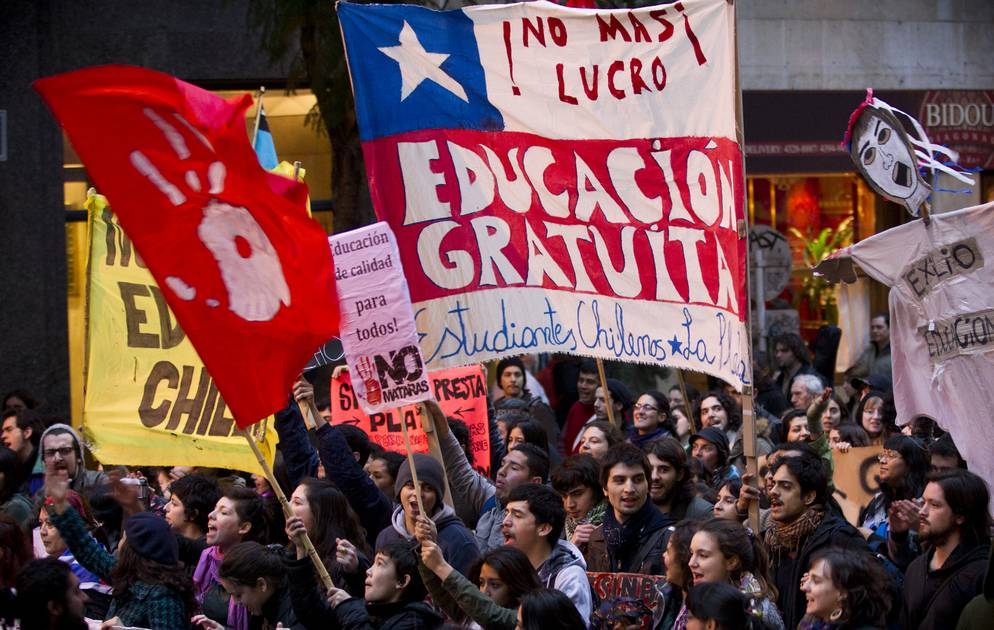

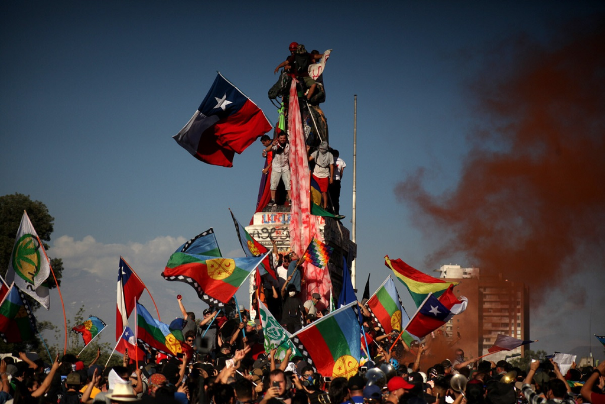

## La idea de confianza política

- La confianza política se define como “la expectativa de que las instituciones políticas funcionen según reglas justas incluso en ausencia de escrutinio constante” (Marien, 2013).
- Indicador intermedio de apoyo político, dirigido a las instituciones políticas del régimen (Montero Gibert et al., 2008; Zmerli, 2022).
- Requisito básico para la consolidación en el tiempo de los regímenes democráticos: facilita la implentación de servicios públicos, el consenso de los perdedores y brinda mayor resistencia a las instituciones en periodos de crisis (Citrin & Stoker, 2018; Newton et al., 2017; Van der Meer & Zmerli, 2017).
- Este indicador ha disminuido sostenidamente en las democracias alrededor del mundo (Valgarsson et al., 2025). En Chile, todas las las instituciones políticas han presenciado una disminución en su confianza durante los últimos 30 años (Bargsted & Somma, 2018; Corporación Latinobarómetro, 2024).

## Confianza política en Chile: análisis longitudinal

Figura 1: **Evolución de la confianza política en Chile: porcentaje de encuestados que reporta ‘mucha’ o ‘algo’ de confianza.**

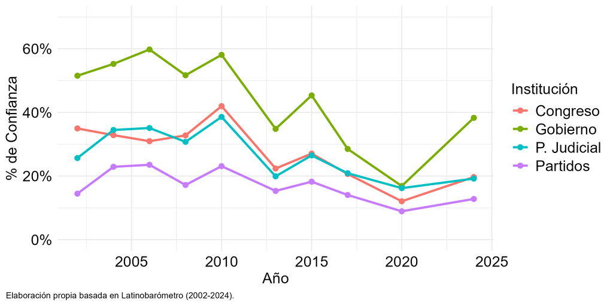

## Confianza política en Chile: análisis comparado

Figura 2: **Confianza política comparada en América Latina: promedio de confianza política.**

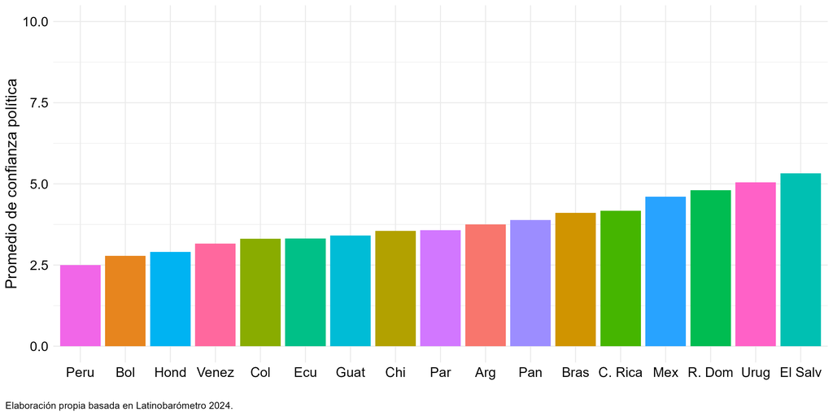

## El estudio de la confianza política

- Dos grupos de factores que explicarían su origen (Mishler & Rose, 2001; Van der Meer & Zmerli, 2017; Zmerli, 2022):
  - Institucional: producto de una **evaluación racional** del desempeño institucional en cumplir con las expectativas de los ciudadanos en distintos ámbitos. Destacan tres indicadores: **desempeño económico**, **corrupción** y **distribución de riqueza**.
  - Sociocultural: **conjunto de orientaciones valóricas y disposiciones** a confiar, cooperar y solidarizar con los otros en función de objetivos comunes. Tiene su pilar en la **confianza generalizada**.
- La evidencia empírica dice que **ambos grupos inciden** en la construcción de confianza política, aunque **las primeras importarían más** que las segundas.

## Problematización

- Las investigaciones previas tienen, al menos, dos grandes limitaciones:
  1. Conciben la relación entre confianza generalizada y confianza política como un vínculo **exclusivamente** directo. Al ser la confianza generalizada un lente para interpretar el mundo, esta podría **moderar la relación** entre percepción del desempeño institucional y confianza política.
  2. Se han construido sobre información de **sociedades de alta confianza generalizada**. Es posible encontrar un panorama diferente en **sociedades son de baja confianza**, como la chilena.
- Se busca superar estas limitaciones mediante la presente propuesta de investigación:

# Propuesta de investigación

- **Pregunta de investigación**: ¿Cómo influyen la percepción del desempeño institucional y la confianza generalizada en la confianza política de los ciudadanos chilenos?
- **Objetivos específicos**:
  - Analizar el rol de la **percepción del desempeño institucional** en la confianza política de los ciudadanos chilenos.
  - Examinar el rol de la **confianza generalizada** en la confianza política de los ciudadanos chilenos.
  - Explorar si varía o no la relación entre la percepción del desempeño institucional y la confianza política al **moderar** por el nivel de confianza generalizada de los ciudadanos chilenos.

# Antecedentes

## Percepción del desempeño institucional

- Confianza de tipo **estratégica** que se puede resumir en la fórmula “A confía en B para que haga *x*” (Hardin, 1999, p. 26). Confiar implicaría un riesgo, por lo que es una **decisión racional** que se toma sobre la base de información.
  - **Desempeño económico**: los ciudadanos evaluarían sus instituciones en función de la capacidad que estas tienen de satisfacer sus expectativas de **incremento en los estándares de vida de la población** (McAllister, 1999; Quaranta & Martini, 2016; Thomassen, 1998).
  - **Corrupción**: los individuos que identifican el **mal uso de fondos públicos para fines privados** como una práctica recurrente al interior de una institución, van a calificar a esta de deshonesta e injusta, tendiendo a confiar menos en ella (Beesley & Hawkins, 2022; Uslaner, 2013).
  - **Justicia distributiva**: en la medida en que los ciudadanos consideren la distribución de ingresos incompatible con los **principios de igualdad, equidad y suficiencia**, percibirán esta distribución como injusta y confiarán menos en las instituciones políticas (Tyler et al., 1985; Tyler, 2015; Zmerli & Castillo, 2015).

## Confianza generalizada

- La confianza generalizada se entiende como la confianza que se deposita sobre **la mayoría de la gente**. En este sentido, no se construye sobre la base de información, sino que mediante una **disposición moral** a confiar en cuanto son parte de nuestra misma comunidad moral (Uslaner, 2002).Se resume en la frase “A confía” (Uslaner, 2002, p. 26).
- Funciona como un lente a través del cual cierto tipo de individuo interpreta el mundo que lo rodea de forma positiva, creyendo en la buena voluntad de los demás (Oskarsson, 2010).
- Esta disposición está a la base de un conjunto de orientaciones y actitudes que se retroalimentan, y que derivan en ciudadanos más dispuestos a participar y a confiar en las instituciones.
- A su vez, estos individuos, al poseer una predisposición a confiar que no depende de la información, serían **menos sensibles a disminuir su confianza** en las instituciones políticas en función de una evaluación negativa de su desempeño al corto plazo.

## Particularidades del caso chileno

- En Chile, la baja en la confianza política ha convivido con mejoras sustantivas en indicadores económicos, baja corrupción política y disminución de la desigualdad de ingreso.
- Necesidad de buscar explicación en factores exógenos, como lo es la erosión del lazo social:
  - Solo un 15% de los chilenos dice confiar en los demás (PNUD, 2024).
  - Circuito del desapego (Araujo, 2025): distanciamiento de los individuos respecto a las normas e instituciones que regulan la vida social.
  - Individuos fuertemente individualizados que perciben a las instituciones políticas como una amenaza.
- En este escenario, es posible que la confianza generalizada tenga un **peso mayor** que la percepción del desempeño institucional en la construcción de la confianza política de los chilenos.

# Estrategia de análisis

## Hipótesis

- *H1*: La percepción de la situación económica nacional se relaciona positivamente con la confianza política. Es decir, los ciudadanos que evalúan de mejor forma la situación económica del país tendrán un mayor nivel de confianza política que los ciudadanos que evalúan de peor forma esta situación.
- *H2*: El progreso en reducir la corrupción se relaciona positivamente con la confianza política. Lo anterior significa que los ciudadanos que perciban un mayor progreso en reducir la corrupción en el país van a tener un mayor nivel de confianza política respecto a los ciudadanos que perciban un menor progreso en reducir la corrupción.
- *H3*: La percepción de justicia distributiva se relaciona positivamente con la confianza política. Esto significa que los ciudadanos que perciban como justa la distribución de ingresos en el país van a tener un mayor nivel de confianza política respecto a los ciudadanos que la perciban como injusta.
- *H4*: La confianza generalizada se relaciona positivamente con la confianza política. Es decir, los ciudadanos que reporten un mayor grado de confianza en la mayoría de las personas van a tener un mayor nivel de confianza política respecto a los ciudadanos que reporten un menor grado de confianza en la mayoría de las personas.

## Hipótesis

- *H5*: La relación entre percepción de la situación económica del país y nivel de confianza política se ve moderada negativamente por la confianza generalizada. Esto significa que el efecto de la percepción de la situación económica del país sobre el nivel de confianza política será menor en ciudadanos que reporten confiar en la mayoría de las personas respecto a ciudadanos que no lo hagan.
- *H6*: La relación entre el progreso en reducir la corrupción y el nivel de confianza política se ve moderada negativamente por la confianza generalizada. Esto quiere decir que el efecto del progreso en reducir la corrupción en el país sobre el nivel de confianza política será menor en ciudadanos que reporten confiar en la mayoría de las personas respecto a ciudadanos que no lo hagan.
- *H7*: La relación entre justicia distributiva y nivel de confianza política se ve moderada negativamente por la confianza generalizada. Lo anterior significa que el efecto de la justicia distributiva sobre el nivel de confianza política será menor en ciudadanos que reporten confiar en la mayoría de las personas respecto a ciudadanos que no lo hagan.
- *H8*: La confianza generalizada presenta una asociación con la confianza política de mayor magnitud que la percepción del desempeño institucional. Lo anterior implica que el efecto de la confianza generalizada sobre la confianza política va a ser de mayor tamaño que el de los distintos indicadores de la percepción del desempeño sobre la misma variable.

## Metodología

- Variables:
  - Dependiente: Indice de confianza política ($\alpha$ = 0.82) con valores de 1 a 10. Incluye confianza en el Gobierno, el Congreso, el Poder Judicial y los Partidos Políticos.
  - Independientes:
    - **Indice de percepción de desempeño económico** ($\alpha$ = 0.80) con valores de 1 a 10. Incluye la referencia a tres periodos (presente, pasado y futuro).
    - **Progreso en reducir la corrupción**. Variable *dummy*, donde “0” indica evaluación negativa y “1” positiva
    - **Justicia distributiva**. Variable *dummy*, donde “0” indica injusticia y “1” justicia.
    - **Confianza generalizada**. Variable *dummy*, donde “0” indica que es cuidadoso en el trato con los demás y “1” que se confía en la mayoría de las personas.
  - Control:
    - **Sociodemográficas**: sexo, edad, religión, educación y ESS.

## Variables 2

[output not shown]

# Resultados

## Descrptivos: situación económica y confianza política

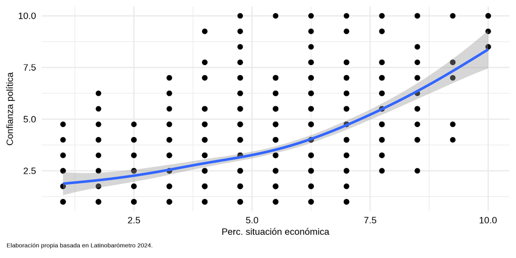

## Descriptivos: progreso en reducir corrupción y confianza política

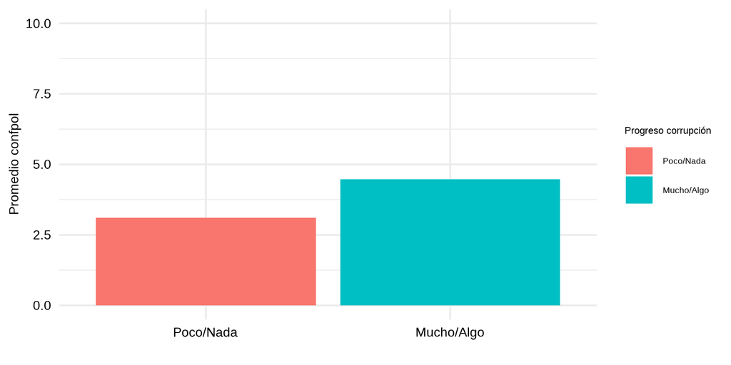

## Descriptivos: justicia distributiva y confianza política

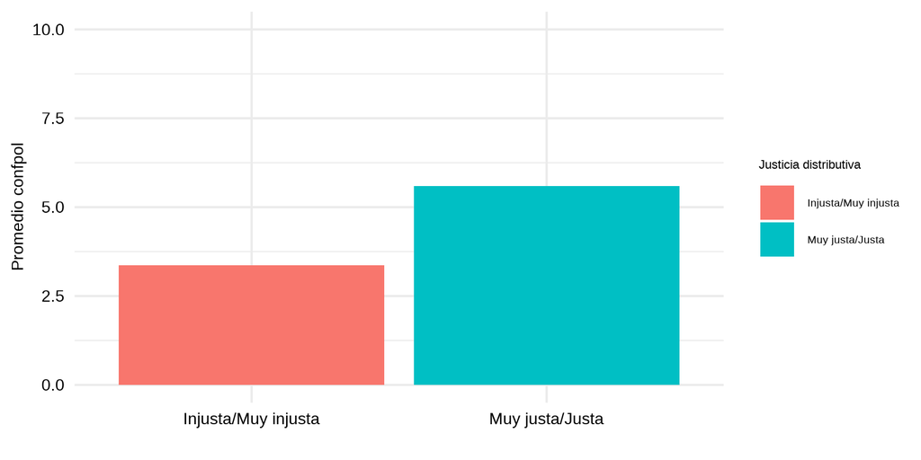

## Descriptivos: confianza generalizada y confianza política

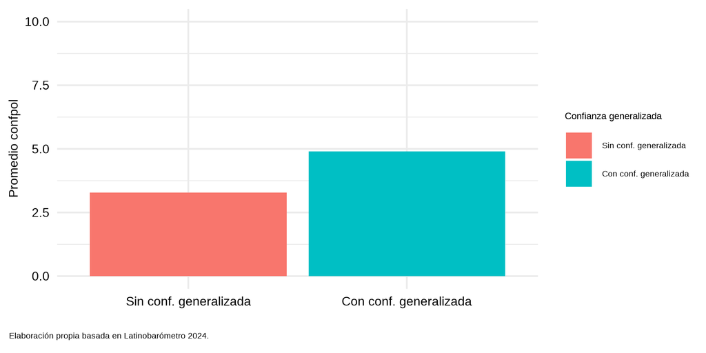

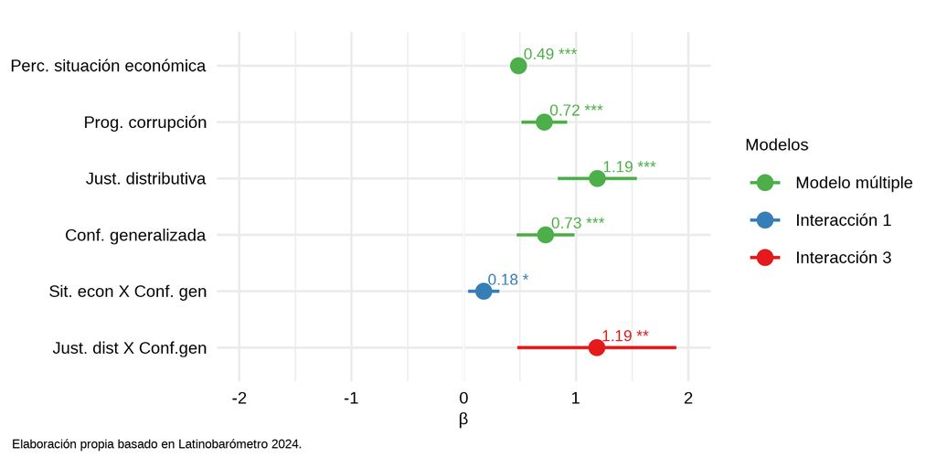

## Regresiones con interacción: perc. situación económica X confianza generalizada

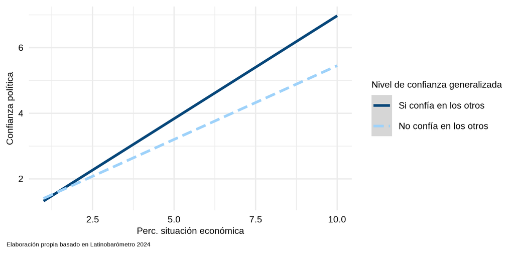

## Regresiones con interacción: justicia distributiva X confianza generalizada

Figura 9: **Gráfico interacción justicia distributiva con confianza generalizada**

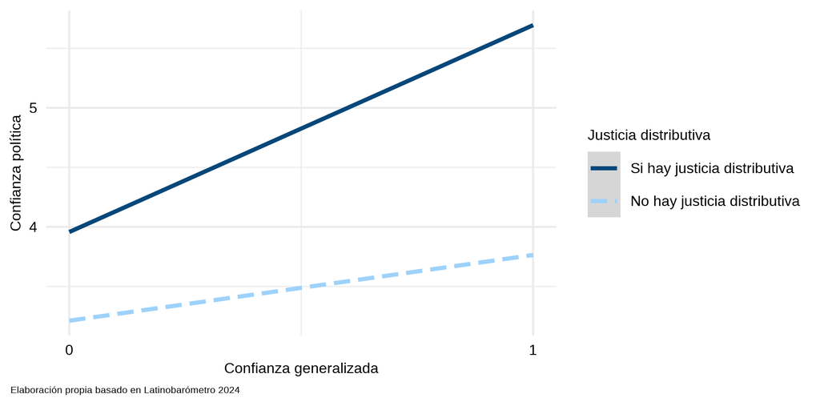

# Discusión

## Hallazgos

# Conclusiones

- Más allá de la dicotomía: la confianza política es un fenómeno complejo, en cuya construcción inciden tanto la evaluación racional del desempeño como la disposición moral a confiar en los demás.
- Para comprender el efecto que tiene la confianza generalizada en la confianza política, hay que superar la concepción de este vínculo como uno **exclusivamente** directo, prestando atención a su efecto moderados.
- La baja confianza en las instituciones chilenas solo se puede entender si se tienen en cuenta tanto los factores endógenos (desempeño institucional) como los factores exógenos (lazo social).

# Proyecciones

- Llevar a cabo modelos de tipo multinivel sobre **datos longitudinales** para analizar cómo estos efectos varían en el tiempo (si es que lo hacen).
- Incluir **variables contextuales** y compararlas con las de percepción.
- Expandir el radio de estudio hacia **mas países** de la región.

# ¡Gracias por su atención!

- **Github del proyecto:** https://github.com/jp-diaz-c/tesis-pregrado

## Apéndice 2: Tablas de regresión sin interacción

[output not shown]

## Referencias

Araujo, K. (2025). *El Circuito Del Desapego. Neoliberalismo, Democratización y Lazo Social*. Pólvora Editorial.

Bargsted, M. A., & Somma, N. M. (2018). La Cultura Política, Diagnóstico y Evolución. En C. Huneeus & O. Avendaño (Eds.), *El Sistema Político de Chile*. LOM Ediciones.

Beesley, C., & Hawkins, D. (2022). Corruption, Institutional Trust and Political Engagement in Peru. *World Development*, *151*, 105743. https://doi.org/10.1016/j.worlddev.2021.105743

Castiglioni, R., & Rovira Kaltwasser, C. (2016). Challenges to Political Representation in Contemporary Chile. *Journal of Politics in Latin America*, *8*(3), 3-24. https://doi.org/10.1177/1866802X1600800301

Citrin, J., & Stoker, L. (2018). Political Trust in a Cynical Age. *Annual Review of Political Science*, *21*(Volume 21, 2018), 49-70. https://doi.org/10.1146/annurev-polisci-050316-092550

Corporación Latinobarómetro. (2024). *Informe Latinobarómetro 2024: La Democracia Resiliente*.

Hardin, R. (1999). Do We Want Trust in Government? En M. E. Warren (Ed.), *Democracy and Trust*. Cambridge University Press. https://doi.org/10.1017/CBO9780511659959.004

Luna, J. P. (2016). Delegative Democracy Revisited: Chile’s Crisis of Representation. *Journal of Democracy*, *27*(3), 129-138.

Marien, S. (2013). Measuring Political Trust across Time and Space. En *Political Trust: Why Context Matters*. ECPR Press.

McAllister, I. (1999). The Economic Performance of Governments. En P. Norris (Ed.), *Critical Citizens* (1.ª ed., pp. 188-203). Oxford University PressOxford. https://doi.org/10.1093/0198295685.003.0009

Mishler, W., & Rose, R. (2001). What Are the Origins of Political Trust?: Testing Institutional and Cultural Theories in Post-communist Societies. *Comparative Political Studies*, *34*(1), 30-62. https://doi.org/10.1177/0010414001034001002

Montero Gibert, J. R., Zmerli, S., & Newton, K. (2008). Confianza Social, Confianza Política y Satisfacción Con La Democracia. *Revista Española de Investigaciones Sociológicas*, *122*, 11-54. https://doi.org/10.5477/cis/reis.122.11

Newton, K., Stolle, D., & Zmerli, S. (2017). Social and Political Trust. En E. M. Uslaner (Ed.), *The Oxford Handbook of Social and Political Trust* (Vol. 1). Oxford University Press. https://doi.org/10.1093/oxfordhb/9780190274801.001.0001

Oskarsson, S. (2010). Generalized Trust and Political Support: A Cross-National Investigation. *Acta Politica*, *45*(4), 423-443. https://doi.org/10.1057/ap.2010.3

PNUD. (2024). *Informe Sobre Desarrollo Humano En Chile 2024. Qué Nos Cuesta Cambiar?: Conducir Los Cambios Para Un Desarrollo Humano Sostenible.* Programa de las Naciones Unidas para el Desarrollo (PNUD).

Quaranta, M., & Martini, S. (2016). Does the Economy Really Matter for Satisfaction with Democracy? Longitudinal and Cross-Country Evidence from the European Union. *Electoral Studies*, *42*, 164-174. https://doi.org/10.1016/j.electstud.2016.02.015

Thomassen, J. (1998). Support for Democratic Values. En H.-D. Klingemann & D. Fuchs (Eds.), *Citizens and the State* (1.ª ed.). Oxford University PressOxford. https://doi.org/10.1093/0198294735.001.0001

Tyler, T. R. (2015). Social Justice. En *APA Handbook of Personality and Social Psychology, Volume 2: Group Processes* (pp. 95-122). American Psychological Association. https://doi.org/10.1037/14342-004

Tyler, T. R., Rasinski, K. A., & McGraw, K. M. (1985). The Influence of Perceived Injustice on the Endorsement of Political Leaders. *Journal of Applied Social Psychology*, *15*(8), 700-725. https://doi.org/10.1111/j.1559-1816.1985.tb02269.x

Uslaner, E. M. (2002). *The Moral Foundations of Trust*. Cambridge University Press.

Uslaner, E. M. (2013). Corruption, the Inequality Trap and Trust in Goverment. En S. Zmerli & M. Hooghe (Eds.), *Political Trust: Why Context Matters*. ECPR Press.

Valgarsson, V., Jennings, W., Stoker, G., Bunting, H., Devine, D., McKay, L., & Klassen, A. (2025). A Crisis of Political Trust? Global Trends in Institutional Trust from 1958 to 2019. *British Journal of Political Science*, *55*, e15. https://doi.org/10.1017/S0007123424000498

Van der Meer, T., & Zmerli, S. (2017). The Deeply Rooted Concern with Political Trust. En S. Zmerli & T. Van Der Meer (Eds.), *Handbook on Political Trust*. Edward Elgar Publishing. https://doi.org/10.4337/9781782545118

Zmerli, S. (2022). Political Trust. En *Encyclopedia of Quality of Life and Well-Being Research* (pp. 1-4). Springer, Cham. https://doi.org/10.1007/978-3-319-69909-7_2202-2

Zmerli, S., & Castillo, J. C. (2015). Income Inequality, Distributive Fairness and Political Trust in Latin America. *Social Science Research*, *52*, 179-192. https://doi.org/10.1016/j.ssresearch.2015.02.003